# Overview of georeferenced data exceeding nominal in ICCAT records

Bastien Grasset

IRDMARBEC  
bastien.grasset@ird.fr

Julien Barde

IRDMARBEC

28 janvier, 2025

Abstract

This document provides an analysis overview of the link between georeferenced and nominal data based on ICCAT 2024 records. Code used for the analysis is available at: https://github.com/bastienird/iotc_report/minor_recap.R and https://github.com/bastienird/iotc_report/about.R The purpose of this report is to highlight discrepancies in the datasets and seek clarification on which data should be considered the most reliable. Specifically, it addresses whether georeferenced data should be adjusted to align with nominal data, or vice versa, and whether these differences stem from variations in data aggregation or disaggregation processes.

# 1 Georeferenced catches exceeding nominal catches

## 1.1 Species/year strata

Table 1.1: Strata with georeferenced catches exceeding nominal catches for species/year comparison

| species | year | measurement_value_nominal | measurement_value_georef_tons | Difference |
| --- | --- | --- | --- | --- |
| ALB | 1976 | 77,171.00 | 86,412.12 | 9,241.12 |
| ALB | 1977 | 76,099.00 | 83,027.08 | 6,928.08 |
| ALB | 1978 | 73,806.00 | 74,257.14 | 451.14 |
| ALB | 1980 | 62,136.60 | 63,766.99 | 1,630.38 |
| ALB | 1982 | 73,616.64 | 75,224.99 | 1,608.35 |
| ALB | 1983 | 67,643.30 | 71,108.12 | 3,464.82 |
| ALB | 1984 | 59,850.35 | 62,643.05 | 2,792.70 |
| ALB | 1985 | 76,051.94 | 89,980.40 | 13,928.46 |
| ALB | 1986 | 88,553.76 | 97,980.21 | 9,426.45 |
| ALB | 1987 | 82,741.06 | 87,364.27 | 4,623.21 |
| ALB | 1989 | 63,342.11 | 63,638.02 | 295.91 |
| ALB | 1994 | 71,813.02 | 73,826.75 | 2,013.73 |
| BIL | 1981 | 116.00 | 127.40 | 11.40 |
| BIL | 1987 | 5.00 | 68.10 | 63.10 |
| BIL | 1988 | 1.00 | 223.90 | 222.90 |
| BIL | 1989 | 1.00 | 222.40 | 221.40 |
| BIL | 1990 | 1.00 | 112.20 | 111.20 |
| BIL | 1993 | 27.00 | 655.50 | 628.50 |
| BIL | 2000 | 37.42 | 1,042.65 | 1,005.23 |
| BIL | 2001 | 25.20 | 458.30 | 433.10 |
| BIL | 2002 | 1.72 | 858.86 | 857.14 |
| BIL | 2003 | 9.39 | 435.54 | 426.15 |
| BIL | 2004 | 31.53 | 131.20 | 99.68 |
| BIL | 2005 | 103.66 | 116.78 | 13.12 |
| BIL | 2007 | 9.35 | 357.64 | 348.29 |
| BIL | 2008 | 12.84 | 109.17 | 96.33 |
| BIL | 2009 | 26.56 | 563.12 | 536.56 |
| BIL | 2010 | 28.99 | 116.35 | 87.36 |
| BIL | 2011 | 121.93 | 137.00 | 15.07 |
| BIL | 2014 | 0.88 | 1.91 | 1.03 |
| SKJ | 1979 | 89,760.00 | 90,140.20 | 380.20 |
| SKJ | 1984 | 127,409.80 | 134,965.53 | 7,555.73 |
| SKJ | 1985 | 119,509.72 | 135,880.26 | 16,370.54 |
| SKJ | 1986 | 123,007.02 | 126,873.46 | 3,866.43 |
| SKJ | 1987 | 119,290.68 | 131,201.68 | 11,911.00 |
| SKJ | 1988 | 144,265.85 | 159,064.97 | 14,799.12 |
| TUN | 2006 | 2,867.45 | 2,901.66 | 34.20 |
| TUN | 2007 | 5,851.01 | 6,610.66 | 759.65 |
| TUN | 2009 | 5,432.14 | 5,450.67 | 18.54 |
| TUN | 2010 | 3,981.23 | 5,251.61 | 1,270.38 |
| TUN | 2011 | 2,768.77 | 3,716.03 | 947.26 |
| TUN | 2012 | 5,236.49 | 8,782.12 | 3,545.63 |
| TUS | 2014 | 3.29 | 81.94 | 78.64 |

This represents 0.15% of catches for the equivalent strata in tons. Some of this strata concern data that is aggregated in lower resolution species group, however could it be possible to precise the data in nominal that is in lower resolution (spatial and temporal) to correspond to the equivalent data in georeferenced (i.e increasing the data for a specific species and decreasing it in the correspondent group). However, for the majority of the years the data superior in georeferenced than in nominal cannot be explain by the aggregation of tunas in TUN/TUS.

Graphical verification in the comparison plot.

NB: Additionally, there are data in numbers that could potentially be converted.

## 1.2 species/year/fishing_fleet strata

If we add the dimension “fishing_fleet” to compare the two datasets, the number of strata concerned increase.

|  | species | year | fishing_fleet | measurement_value_nominal | measurement_value_georef_tons | Difference | measurement_unit | measurement_value | time_start |
| --- | --- | --- | --- | --- | --- | --- | --- | --- | --- |
| 1 | SKJ | 1988 | GHA | 26597 | 64395.469 | 37798.469 | t | 37798.469 | 1988-01-01 |
| 2 | SKJ | 1987 | GHA | 24347 | 56069.378 | 31722.378 | t | 31722.378 | 1987-01-01 |
| 3 | SKJ | 1985 | GHA | 19082 | 45350.46 | 26268.46 | t | 26268.46 | 1985-01-01 |
| 4 | ALB | 1985 | TWN | 34542 | 58546.8 | 24004.8 | t | 24004.8 | 1985-01-01 |
| 5 | SKJ | 1986 | GHA | 22268 | 45859.358 | 23591.358 | t | 23591.358 | 1986-01-01 |
| 6 | ALB | 1986 | TWN | 47238 | 65289.2 | 18051.2 | t | 18051.2 | 1986-01-01 |
| 7 | YFT | 1985 | GHA | 12550 | 28892.109 | 16342.109 | t | 16342.109 | 1985-01-01 |
| 8 | ALB | 1977 | TWN | 29815 | 45749.9 | 15934.9 | t | 15934.9 | 1977-01-01 |
| 9 | SKJ | 1984 | GHA | 20697 | 36449.831 | 15752.831 | t | 15752.831 | 1984-01-01 |
| 10 | YFT | 1986 | GHA | 11821 | 27117.152 | 15296.152 | t | 15296.152 | 1986-01-01 |

[output cut: 90 more lines]

This represents 0.77% of catches for the equivalent strata in tons.

# 2 Appendices

## 2.1 Graphical verification of georef_sup_nom consistency

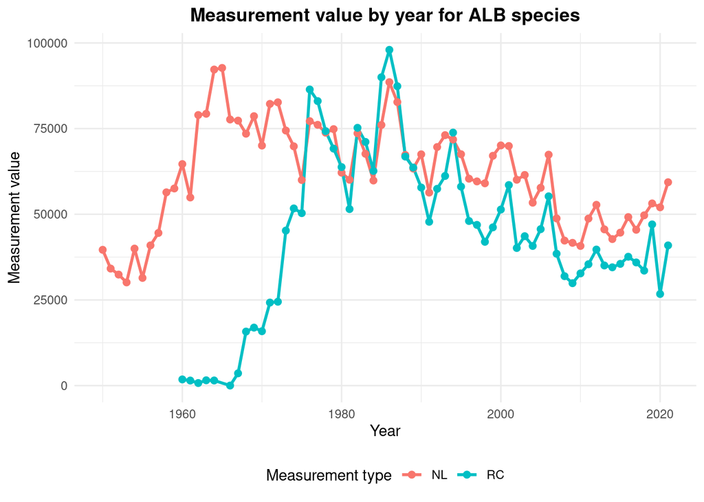

We confirm that in for several years, there is an inversion in the difference curve.